# Chapter 04

Scott Spencer

8/22/2018

The code below is meant as a directly-in-Stan translation of the examples in Chapter 4 of McElreath’s *Statistical Rethinking*.

I’ll use the following packages throughout:

```r
library(dplyr); library(tidyr); library(rstan); library(ggplot2); library(ggthemes)
```

For graphics, I’ll set ggplot’s theme like so, `theme_set(theme_tufte(base_family = 'sans'))`.

# Chapter 4

## 4.1 Why normal distributions are normal

### 4.1.1 Normal by addition

Simulate a random walk.

```r
N_reps <- 1000; N_steps <- 16

set.seed(TRUE)

d <-
  replicate(N_reps, runif(N_steps, -1, 1)) %>%               # simulate 16 steps
  as_tibble() %>%                                            # convert to tibble
  rbind(0, .) %>%                                            # include row of zeros for no steps
  mutate(step = 0:N_steps) %>%                               # add variable for number of steps
  gather(key, value, -step) %>%                              # convert data to long format
  mutate(person = rep(seq(N_reps), each = N_steps + 1)) %>%  # adds person index
  group_by(person) %>%                                       # group data by person
  mutate(position = cumsum(value)) %>%                       # calculate steps accumulated by person
  ungroup()                                                  # ungroup
```

Figure 4.2. Plot distributions of final positions.

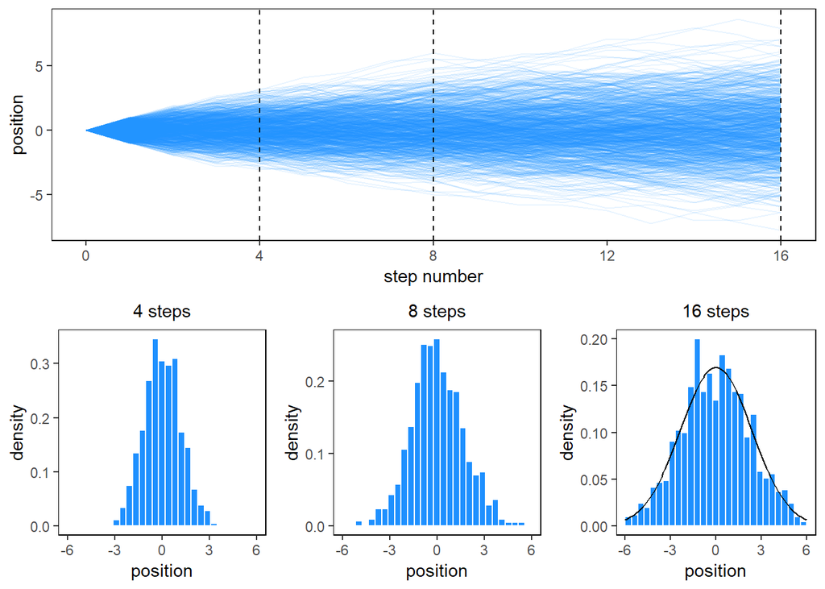

```r
p1 <- ggplot(d) +
  theme(panel.border = element_rect(fill = NA)) +
  geom_line(aes(step, position, group = person),
            color = 'dodgerblue', alpha = .1) +
  geom_vline(xintercept = c(4, 8, 16), linetype = 'dashed') +
  scale_x_continuous(breaks = c(0, 4, 8, 12, 16)) +
  labs(x = 'step number', y = 'position')

p2 <- ggplot(d %>% filter(step == 4)) +
  theme(panel.border = element_rect(fill = NA)) +
  geom_histogram(aes(x = position, y = ..density..), fill = 'dodgerblue', color = 'white') +
  theme(plot.subtitle = element_text(hjust = .5)) +
  scale_x_continuous(limits = c(-6, 6)) +
  labs(x = 'position', y = 'density', subtitle = '4 steps')

p3 <- ggplot(d %>% filter(step == 8)) +
  theme(panel.border = element_rect(fill = NA)) +
  geom_histogram(aes(x = position, y = ..density..), fill = 'dodgerblue', color = 'white') +
  theme(plot.subtitle = element_text(hjust = .5)) +
  scale_x_continuous(limits = c(-6, 6)) +
  labs(x = 'position', y = 'density', subtitle = '8 steps')

p4 <- ggplot(d %>% filter(step == 16)) +
  theme(panel.border = element_rect(fill = NA)) +
  geom_histogram(aes(x = position, y = ..density..), fill = 'dodgerblue', color = 'white') +
  stat_function(fun = dnorm, args = list(mean = 0, sd = sd(d$position[d$step==16]))) +
  theme(plot.subtitle = element_text(hjust = .5)) +
  scale_x_continuous(limits = c(-6, 6)) +
  labs(x = 'position', y = 'density', subtitle = '16 steps')

library(gridExtra); library(gtable)
grid.arrange(p1, p2, p3, p4, layout_matrix = rbind(c(1), c(2, 3, 4)), nrow = 2)
```

## 4.3 A gaussian model of height

First we load in the data, and get a subset where age is greater than 18.

```r
data('Howell1', package = 'rethinking')
d  <- Howell1; rm(Howell1)
d2 <- d %>% filter(age >= 18)
```

### 4.3.2 The model

Here’s the Stan code, which is compiled and stored in object `m04_1` (which is specified but not shown below in the code chunk header):

```stan
data {
  int<lower=1> N;
  vector[N] height;
}
parameters {
  real mu;
  real<lower=0,upper=50> sigma;
}
model {
  target += normal_lpdf(height | mu, sigma);
  target += normal_lpdf(mu | 178, 20);
}
```

Stan programs accept data in a list format, so we reorganize `d2`:

```r
dat <- list(N = NROW(d2),
            height = d2$height)
```

We sample from our model:

```r
fit04_1 <- sampling(m04_1, data = dat, iter = 1000, chains = 2, cores = 2)
```

And summarise it below:

```r
print(fit04_1, probs = c(0.10, 0.5, 0.9))
```

```
## Inference for Stan model: 0adb03129ffdc2258f4cc0e69ae10ee8.
## 2 chains, each with iter=1000; warmup=500; thin=1;
## post-warmup draws per chain=500, total post-warmup draws=1000.
##
##           mean se_mean   sd      10%      50%      90% n_eff Rhat
## mu      154.61    0.01 0.40   154.10   154.61   155.13  1167    1
## sigma     7.75    0.01 0.28     7.39     7.74     8.11   927    1
## lp__  -1223.06    0.04 0.94 -1224.25 -1222.80 -1222.22   495    1
##
## Samples were drawn using NUTS(diag_e) at Wed Jan 23 12:06:08 2019.
## For each parameter, n_eff is a crude measure of effective sample size,
## and Rhat is the potential scale reduction factor on split chains (at
## convergence, Rhat=1).
```

Following the examples in McElreath, we modify the Stan model to show the effect of a narrow prior:

```stan
data {
  int<lower=1> N;
  vector[N] height;
}
parameters {
  real mu;
  real<lower=0,upper=50> sigma;
}
model {
  target += normal_lpdf(height | mu, sigma);
  target += normal_lpdf(mu | 178, 0.1);
}
```

After sampling,

```r
fit04_2 <- sampling(m04_2, data = dat, iter = 1000, chains = 2, cores = 2)
```

We summarise the model:

```r
print(fit04_2, probs = c(0.10, 0.5, 0.9))
```

```
## Inference for Stan model: f8fd577ebd79b2572335bad2276a90b6.
## 2 chains, each with iter=1000; warmup=500; thin=1;
## post-warmup draws per chain=500, total post-warmup draws=1000.
##
##           mean se_mean   sd      10%      50%      90% n_eff Rhat
## mu      177.87    0.00 0.11   177.73   177.87   178.00   700    1
## sigma    24.54    0.04 0.94    23.39    24.48    25.71   718    1
## lp__  -1623.73    0.05 1.06 -1625.17 -1623.39 -1622.79   428    1
##
## Samples were drawn using NUTS(diag_e) at Wed Jan 23 12:06:52 2019.
## For each parameter, n_eff is a crude measure of effective sample size,
## and Rhat is the potential scale reduction factor on split chains (at
## convergence, Rhat=1).
```

The strong prior on `mu` held it almost unchanged, but the weak prior on `sigma` allowed the data to move it’s posterior. Let’s look at their correlation. To do this, we need to calculate the posterior of the predictors:

```r
post <- as.data.frame(fit04_1)
```

The parameter covariance matrix is,

```r
post_cov <- post %>% select(mu, sigma) %>% cov()
post_cov
```

```
##                 mu        sigma
## mu     0.160898794 -0.004401004
## sigma -0.004401004  0.079930758
```

and the correlation matrix is:

```r
post %>% select(mu, sigma) %>% cor()
```

```
##                mu       sigma
## mu     1.00000000 -0.03880775
## sigma -0.03880775  1.00000000
```

Covariate `mu` gives no information about `sigma` and vice versa.

#### Overthinking

```r
coef_mean <- post %>% select(mu, sigma) %>% summarise_all(mean) %>% as.numeric
post <- MASS::mvrnorm(n = 1e4, mu = coef_mean, Sigma = post_cov)
```

### 4.4.2 Fitting the model

```stan
data {
  int<lower=1> N;
  vector[N] height;
  vector[N] weight;
}
parameters {
  real alpha;
  real beta;
  real<lower=0,upper=50> sigma;
}
model {
  vector[N] mu = alpha + beta * weight;
  target += normal_lpdf(height | mu, sigma);
  target += normal_lpdf(alpha | 178, 20);
  target += normal_lpdf(beta | 0, 10);
}
```

Sampling,

```r
dat <- list(N = NROW(d2),
            height = d2$height,
            weight = d2$weight)
fit04_3 <- sampling(m04_3, data = dat, iter = 1000, chains = 2, cores = 2)
```

### 4.4.3 Interpreting the model fit

```r
print(fit04_3, probs = c(0.10, 0.5, 0.9))
```

```
## Inference for Stan model: 06884dcdf3b2cd56de0756975bcf14f2.
## 2 chains, each with iter=1000; warmup=500; thin=1;
## post-warmup draws per chain=500, total post-warmup draws=1000.
##
##           mean se_mean   sd      10%      50%      90% n_eff Rhat
## alpha   114.78    0.11 1.90   112.28   114.76   117.18   317 1.00
## beta      0.89    0.00 0.04     0.83     0.88     0.94   314 1.00
## sigma     5.10    0.01 0.20     4.84     5.11     5.35   309 1.01
## lp__  -1083.28    0.09 1.24 -1084.92 -1082.96 -1082.03   207 1.02
##
## Samples were drawn using NUTS(diag_e) at Wed Jan 23 12:07:38 2019.
## For each parameter, n_eff is a crude measure of effective sample size,
## and Rhat is the potential scale reduction factor on split chains (at
## convergence, Rhat=1).
```

```r
post <- as.data.frame(fit04_3)
post %>% select(alpha, beta, sigma) %>% cor()
```

```
##             alpha        beta       sigma
## alpha  1.00000000 -0.98933678  0.08529822
## beta  -0.98933678  1.00000000 -0.08920357
## sigma  0.08529822 -0.08920357  1.00000000
```

We find that parameters `alpha` and `beta` are highly correlated.

Let’s center the data for `weight`.

```r
d2 <- d2 %>% mutate(weight.c = (weight - mean(weight)))

dat <- list(N = NROW(d2),
            height = d2$height,
            weight_c = d2$weight.c)
```

Recode the Stan model,

```stan
data {
  int<lower=1> N;
  vector[N] height;
  vector[N] weight_c;
}
parameters {
  real alpha;
  real beta;
  real<lower=0,upper=50> sigma;
}
model {
  vector[N] mu = alpha + beta * weight_c;
  target += normal_lpdf(height | mu, sigma);
  target += normal_lpdf(alpha | 178, 20);
  target += normal_lpdf(beta | 0, 10);
}
```

And sampling from the new model,

```r
fit04_4 <- sampling(m04_4, data = dat, iter = 1000, chains = 2, cores = 2)
```

gives us:

```r
print(fit04_4, probs = c(0.10, 0.5, 0.9))
```

```
## Inference for Stan model: 9fc0741d99a0c9ebf49de4dd40376231.
## 2 chains, each with iter=1000; warmup=500; thin=1;
## post-warmup draws per chain=500, total post-warmup draws=1000.
##
##           mean se_mean   sd      10%      50%      90% n_eff Rhat
## alpha   154.59    0.01 0.28   154.24   154.59   154.95   844    1
## beta      0.90    0.00 0.04     0.84     0.90     0.96  1244    1
## sigma     5.11    0.01 0.20     4.86     5.11     5.36   918    1
## lp__  -1078.86    0.06 1.21 -1080.43 -1078.59 -1077.62   445    1
##
## Samples were drawn using NUTS(diag_e) at Wed Jan 23 12:08:22 2019.
## For each parameter, n_eff is a crude measure of effective sample size,
## and Rhat is the potential scale reduction factor on split chains (at
## convergence, Rhat=1).
```

With centering, we can interpret `alpha` as the average height at the centered (average) weight. We an also see that centering removed the correlation between `alpha` and `beta`:

```r
post <- as.data.frame(fit04_4)
post %>% select(alpha, beta, sigma) %>% cor()
```

```
##             alpha        beta       sigma
## alpha  1.00000000 -0.02117808  0.02054022
## beta  -0.02117808  1.00000000 -0.07612229
## sigma  0.02054022 -0.07612229  1.00000000
```

#### 4.4.3.2 Plotting posterior inference against the data

Figure 4.4. Plot original data against the mean intercept and slope:

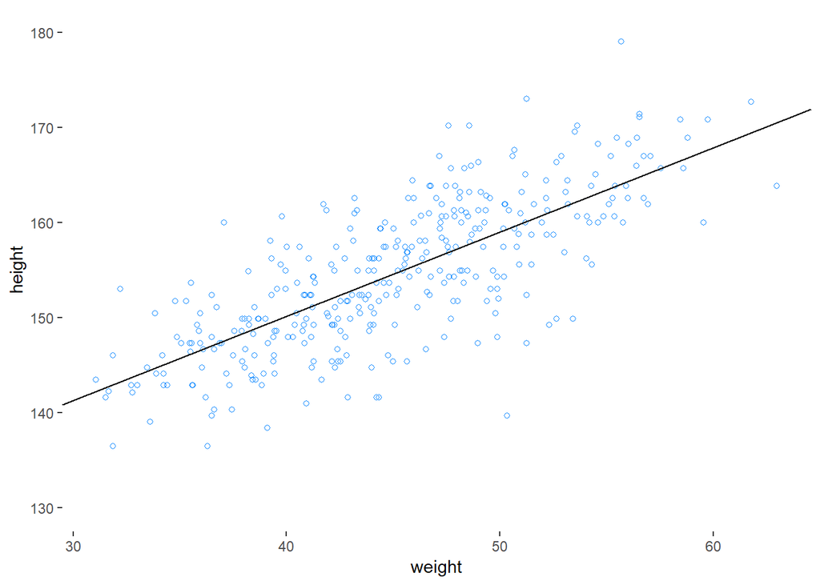

```r
post <- as.data.frame(fit04_3)
p <- ggplot() + lims(y = c(130, 180))

p1 <- p +
  geom_point(data = d2,
             aes(weight, height),
             shape = 1, color = 'dodgerblue') +
  geom_abline(intercept = mean(post$alpha), slope = mean(post$beta))
p1
```

Next, we’ll show how uncertainty depends on how much data is used to fit the model. We’ll use the first `10`, `50`, `150`, and `352` observations, respectively. With Stan, we have to re-sample the model each time.

```r
N <- 10
dat <- list(N = N,
            height = d2[1:N,]$height,
            weight = d2[1:N,]$weight)
fit04_3_1 <- sampling(m04_3, data = dat, iter = 1000, chains = 2, cores = 2)
post1 <- as.data.frame(fit04_3_1)

N <- 50
dat <- list(N = N,
            height = d2[1:N,]$height,
            weight = d2[1:N,]$weight)
fit04_3_2 <- sampling(m04_3, data = dat, iter = 1000, chains = 2, cores = 2)
post2 <- as.data.frame(fit04_3_2)

N <- 150
dat <- list(N = N,
            height = d2[1:N,]$height,
            weight = d2[1:N,]$weight)
fit04_3_3 <- sampling(m04_3, data = dat, iter = 1000, chains = 2, cores = 2)
post3 <- as.data.frame(fit04_3_3)

N <- 352
dat <- list(N = N,
            height = d2[1:N,]$height,
            weight = d2[1:N,]$weight)
fit04_3_4 <- sampling(m04_3, data = dat, iter = 1000, chains = 2, cores = 2)
post4 <- as.data.frame(fit04_3_4)
```

Figure 4.5. Let’s graphically compare them:

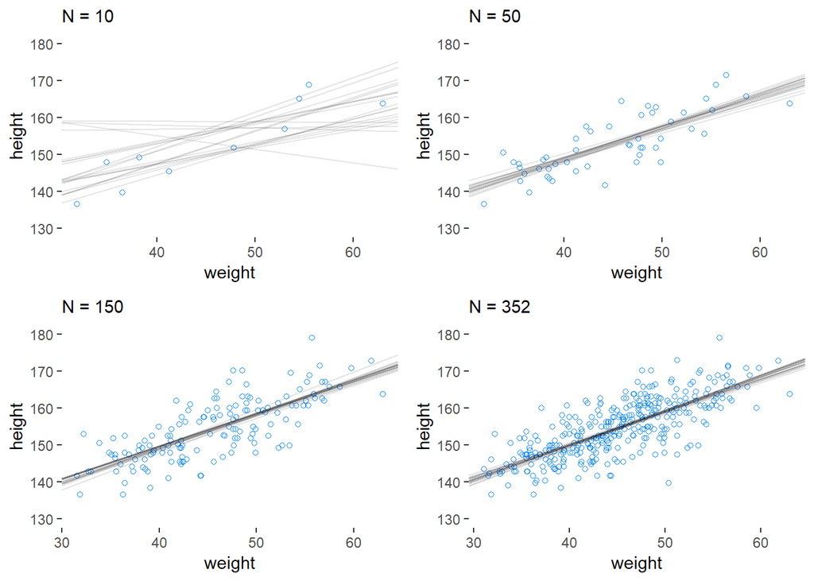

```r
N <- 10
p1 <- p +
  geom_point(data = d2[1:N,],
             aes(weight, height),
             shape = 1, color = 'dodgerblue') +
  geom_abline(data = post1[1:20,],
              aes(intercept = alpha, slope = beta),
              alpha = .1) +
  labs(subtitle="N = 10")

N <- 50
p2 <- p +
  geom_point(data = d2[1:N,],
             aes(weight, height),
             shape = 1, color = 'dodgerblue') +
  geom_abline(data = post2[1:20,],
              aes(intercept = alpha, slope = beta),
              alpha = .1 ) +
  labs(subtitle="N = 50")

N <- 150
p3 <- p +
  geom_point(data = d2[1:N,],
             aes(weight, height),
             shape = 1, color = 'dodgerblue') +
  geom_abline(data = post3[1:20,],
              aes(intercept = alpha, slope = beta),
              alpha = .1 ) +
  labs(subtitle="N = 150")

N <- 352
p4 <- p +
  geom_point(data = d2[1:N,],
             aes(weight, height),
             shape = 1, color = 'dodgerblue') +
  geom_abline(data = post4[1:20,],
              aes(intercept = alpha, slope = beta),
              alpha = .1 ) +
  labs(subtitle="N = 352")

library(gridExtra)
grid.arrange(p1, p2, p3, p4, nrow = 2)
```

Figure 4.6. Let’s look at just the weight of `50` kg.

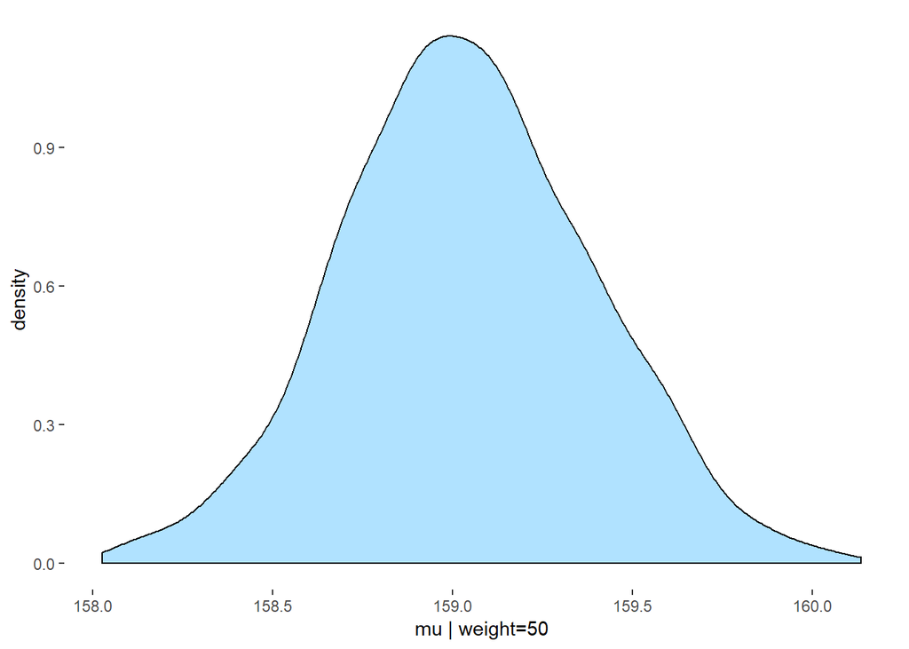

```r
mu_at_50 <- post$alpha + post$beta * 50
ggplot() +
  geom_density(aes(x = mu_at_50), fill = 'lightskyblue1') +
  labs(x = 'mu | weight=50')
```

The Highest Posterior Density Interval (HPDI) with a credible interval of 80 percent is,

```r
HDInterval::hdi(mu_at_50, credMass = 0.8)[1:2]
```

```
##    lower    upper
## 158.5665 159.4527
```

Figure 4.7. The density at each weight can be shown as follows:

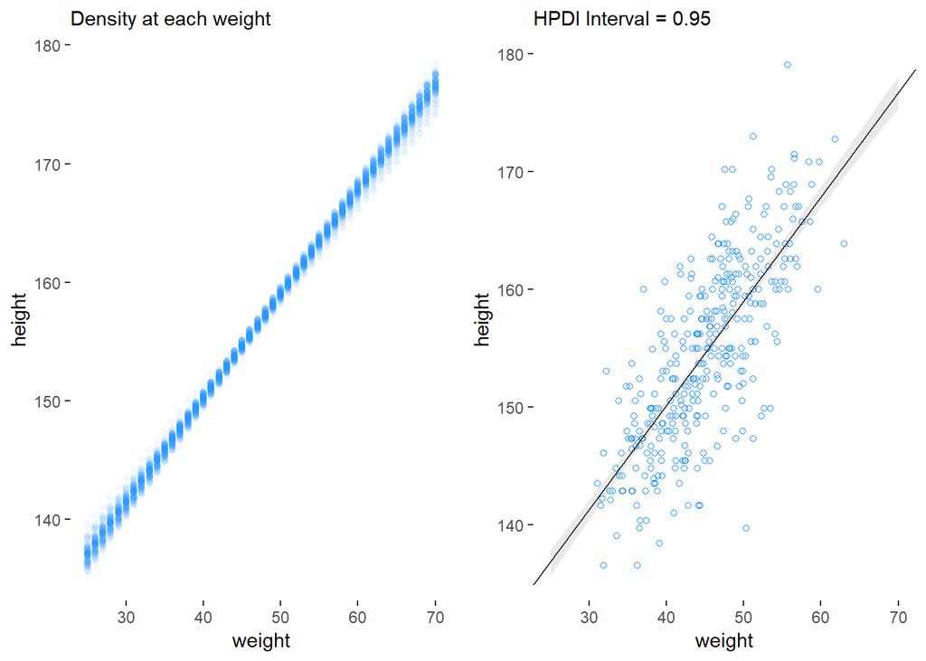

```r
f_mu <- function(x) post$alpha + post$beta * x
weight_new <- seq(25, 70)

mu <-
  sapply(weight_new, f_mu) %>%
  as_tibble() %>%
  rename_all(function(x) weight_new) %>%
  mutate(Iter = row_number()) %>%
  gather(weight, height, -Iter) %>%
  group_by(weight) %>%
  mutate(hpdi_l = HDInterval::hdi(height, credMass = 0.8)[1],
         hpdi_h = HDInterval::hdi(height, credMass = 0.8)[2]) %>%
  mutate(mu = mean(height)) %>%
  ungroup() %>%
  mutate(weight = as.integer(weight))

p <- ggplot()
p1 <- p +
  geom_point(data = mu %>% filter(Iter < 101),
             aes(weight, height), alpha = .05, color = 'dodgerblue') +
  labs(subtitle="Density at each weight")

p2 <- p +
  geom_point(data = d2,
             aes(weight, height), shape = 1, color = 'dodgerblue') +
  geom_ribbon(data = mu,
              aes(x = weight, ymin = hpdi_l, ymax = hpdi_h),
              alpha = .1) +
  geom_abline(data = post,
              aes(intercept = mean(alpha), slope = mean(beta))) +
  labs(subtitle="HPDI Interval = 0.95")

grid.arrange(p1, p2, nrow = 1)
```

#### 4.4.3.5. Prediction intervals

Figure 4.8

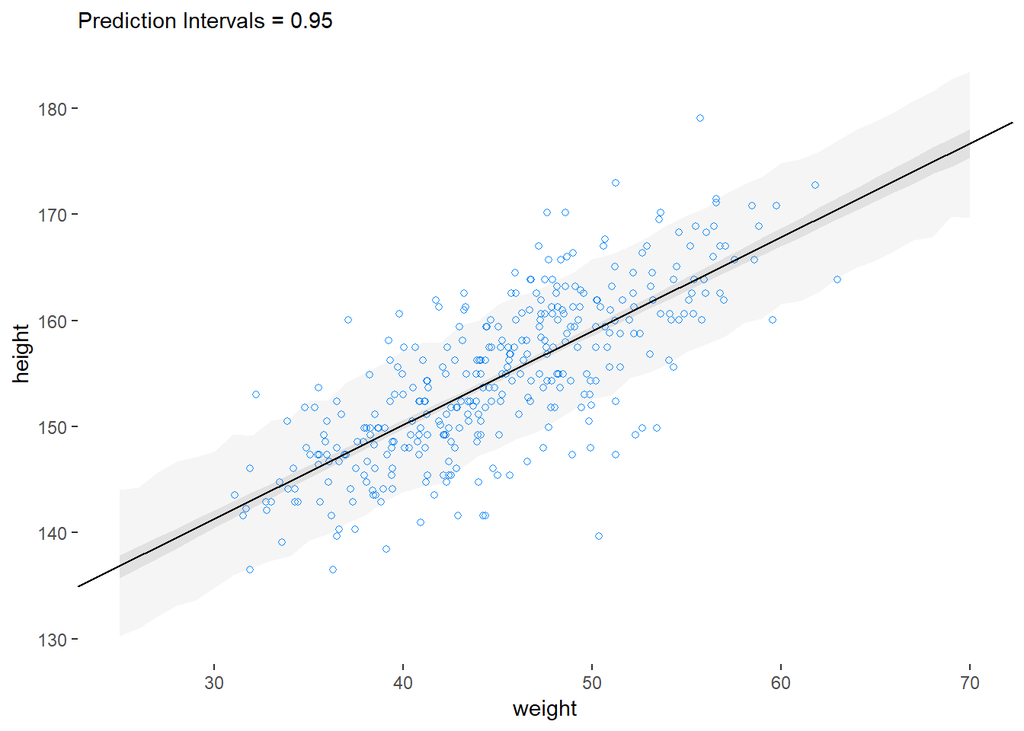

```r
sim_ht <-
  sapply(weight_new,
         function(x)
           rnorm(NROW(post),
                 post$alpha + post$beta * x,
                 post$sigma)) %>%
  as_tibble() %>%
  rename_all(function(x) weight_new) %>%
  mutate(Iter = row_number()) %>%
  gather(weight, height, -Iter) %>%
  group_by(weight) %>%
  mutate(pi_l = rethinking::PI(height, prob = 0.8)[1],
         pi_h = rethinking::PI(height, prob = 0.8)[2]) %>%
  ungroup() %>%
  mutate(weight = as.integer(weight))

p2 + geom_ribbon(data = sim_ht,
                 mapping = aes(x=weight, ymin=pi_l, ymax=pi_h), alpha = .05) +
  labs(subtitle = 'Prediction Intervals = 0.95')
```

## 4.5 Polynomial regression

First, we standardize our weight.

```r
d <- d %>% mutate(weight.z = (weight - mean(weight)) / sd(weight))
```

Next, we code a Stan program.

```stan
data {
  int N;
  vector[N] height;
  vector[N] weight_z;
}
parameters {
  real alpha;
  real beta1;
  real beta2;
  real<lower=0,upper=50> sigma;
}
model {
  vector[N] mu = alpha + beta1 * weight_z + beta2 * (weight_z .* weight_z);
  target += normal_lpdf(height | mu, sigma);
  target += normal_lpdf(alpha | 140, 100);
  target += normal_lpdf(beta1 | 0, 10);
  target += normal_lpdf(beta2 | 0, 10);
  target += uniform_lpdf(sigma | 0, 50);
}
```

Now, we organize the data and sample.

```r
dat <- list(
  N = NROW(d),
  height = d$height,
  weight_z = d$weight.z
)

fit04_5 <- sampling(m04_5, data = dat, iter = 1000, chains = 2, cores = 2)
```

Here’s a model summary.

```r
print(fit04_5, probs = c(0.1, 0.5, 0.9))
```

```
## Inference for Stan model: a89b76268c1e824d751dc68072367e7b.
## 2 chains, each with iter=1000; warmup=500; thin=1;
## post-warmup draws per chain=500, total post-warmup draws=1000.
##
##           mean se_mean   sd      10%      50%      90% n_eff Rhat
## alpha   146.67    0.02 0.38   146.19   146.67   147.15   508 1.01
## beta1    21.41    0.01 0.29    21.03    21.40    21.78   526 1.00
## beta2    -8.41    0.01 0.28    -8.78    -8.40    -8.07   491 1.01
## sigma     5.79    0.01 0.17     5.57     5.79     6.02   908 1.00
## lp__  -1742.28    0.07 1.29 -1744.09 -1742.00 -1740.87   375 1.00
##
## Samples were drawn using NUTS(diag_e) at Wed Jan 23 12:09:22 2019.
## For each parameter, n_eff is a crude measure of effective sample size,
## and Rhat is the potential scale reduction factor on split chains (at
## convergence, Rhat=1).
```

Figure 4.9 (b). Let’s graphically review.

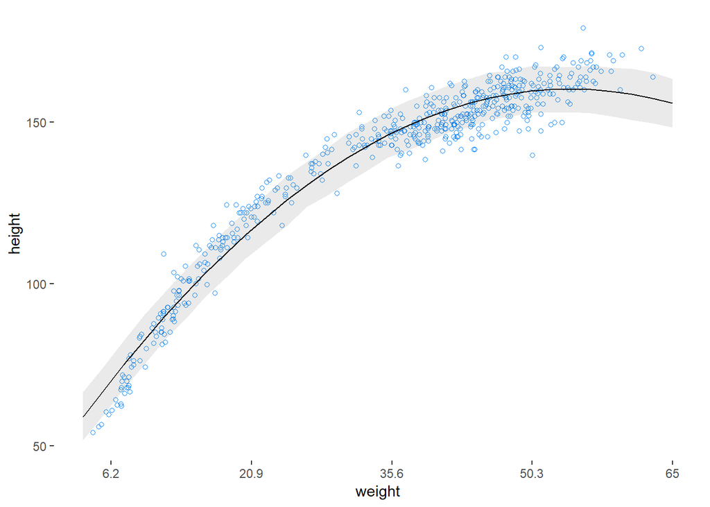

```r
post <- as.data.frame(fit04_5)
weight_z_new <- seq(-2.2, 2, length.out = 30)

f_mu <- function(x) post$alpha + post$beta1 * x + post$beta2 * (x ^ 2)

mu <-
  sapply(weight_z_new, f_mu) %>%
  as_tibble() %>%
  rename_all(function(x) weight_z_new) %>%
  mutate(Iter = row_number()) %>%
  gather(weight_z, height, -Iter) %>%
  group_by(weight_z) %>%
  mutate(hpdi_l = HDInterval::hdi(height, credMass = 0.8)[1],
         hpdi_h = HDInterval::hdi(height, credMass = 0.8)[2]) %>%
  mutate(mu = mean(height)) %>%
  ungroup() %>%
  mutate(weight_z = as.numeric(weight_z))

sim_ht <-
  sapply(weight_z_new,
         function(x)
           rnorm(NROW(post),
                 post$alpha + post$beta1 * x + post$beta2 * (x ^ 2),
                 post$sigma)) %>%
  as_tibble() %>%
  rename_all(function(x) weight_z_new) %>%
  mutate(Iter = row_number()) %>%
  gather(weight_z, height, -Iter) %>%
  group_by(weight_z) %>%
  mutate(pi_l = rethinking::PI(height, prob = 0.8)[1],
         pi_h = rethinking::PI(height, prob = 0.8)[2],
         mu = mean(height)) %>%
  ungroup() %>%
  mutate(weight_z = as.numeric(weight_z))

rescale <- seq(-2, 2, by = 1)

ggplot() +
  geom_point(data = d,
             aes(weight.z, height), shape = 1, color = 'dodgerblue') +
  geom_ribbon(data = sim_ht,
              aes(x = weight_z, ymin = pi_l, ymax = pi_h), alpha = .1) +
  geom_line(data = mu,
            aes(weight_z, mu)) +
  theme_tufte(base_family = 'sans') +
  scale_x_continuous(breaks = rescale,
                     labels = round(rescale * sd(d$weight) + mean(d$weight), 1)) +
  labs(x = 'weight')
```